# Coral reef thermal seasonality: regional pooling, breakpoint model, and Figure 2

SST seasonality metrics project

2026-09-15

## Scope of this notebook

This notebook reproduces, in R, the statistical modeling and figure-building steps behind Figure 2: regional random-effects pooling across 81 reef sites, a validated breakpoint (threshold) model, the derived comparison between phase-shift magnitude and timing precision, and the assembled 6-panel figure.

**It intentionally does not re-derive the underlying per-site metrics from raw sea-surface-temperature (SST) data.** Those per-site numbers (seasonal mean/amplitude trends, phase-shift-over-time, phase circular SD, cue reliability rho) come from harmonic regression and circular-statistics methods already implemented, tested, and validated in this project’s Python pipeline. Re-implementing harmonic fitting and bootstrap trend testing a second time in R would duplicate that work and risks introducing silent numerical drift between two independent implementations without adding scientific value. Instead, this notebook takes the per-site outputs of that pipeline as its documented starting point (see `data/README` / the Data section below for exactly which upstream tables each input file was exported from) and performs, natively in R, every step from there onward: pooling, breakpoint estimation, and figure construction.

Every new R routine used here (`dersimonian_laird()`, `grid_search_breakpoint()`) is a line-for-line port of the corresponding validated Python function, and the pooled M-trend estimate below is cross-checked against the already-published Python result before anything is built on top of it.

## Setup

```r
suppressPackageStartupMessages({
  library(ggplot2)
  library(dplyr)
  library(tidyr)
  library(patchwork)
  library(ggrepel)
  library(scales)
})

source("R/pooling.R")
source("R/breakpoint.R")

MIN_PT <- 8
theme_set(
  theme_bw(base_size = MIN_PT) +
    theme(
      panel.grid = element_blank(),
      axis.text = element_text(size = MIN_PT, colour = "black"),
      axis.title = element_text(size = MIN_PT, colour = "black"),
      plot.title = element_blank()
    )
)

BLUE <- "#0072B2"
GREEN <- "#009E73"
ORANGE <- "#D55E00"

REGION_LABELS <- c(
  Western_Atlantic_Caribbean_Brazil = "Western Atlantic & Caribbean",
  Red_Sea_Persian_Gulf = "Red Sea & Persian Gulf",
  Coral_Triangle_SE_Asia = "Coral Triangle & SE Asia",
  South_Central_Pacific_Polynesia = "South Central Pacific",
  Eastern_Atlantic_West_Africa = "Eastern Atlantic & West Africa",
  Western_Central_Pacific = "Western & Central Pacific",
  Central_Indian_Ocean = "Central Indian Ocean",
  Western_Indian_Ocean = "Western Indian Ocean",
  Australia = "Australia",
  Eastern_Pacific = "Eastern Pacific",
  ORIGINAL_9 = "Focal subset"
)
```

## Data

All input tables live under `data/`. Each is a per-site (or per-site-daily) extract of an already-validated Python output table:

| File | Rows | Columns | Source (upstream Python table) |
| --- | --- | --- | --- |
| `site_trends_M_A1.csv` | 162 (81 sites x 2 axes) | `site_id, region, axis, slope, slope_ci_lo, slope_ci_hi` | `extension/axes81/tables/axes81_1b_trends.csv`, filtered to `period=="full"`, `axis` in `{M, A1}` |
| `site_phase_shift.csv` | 81 | `site_id, region, shift_days, shift_ci_lo, shift_ci_hi` | `extension/axes81/tables/axes81_1b_phase_block_shift.csv`, `period=="full"` |
| `site_phase_sd_A1.csv` | 81 | `site_id, region, pixel_lat, pixel_lon, phase_sd_days, phase_R, mean_A1` | `extension/axes81/tables/axes81_2d_phase_sd_distribution.csv` |
| `site_rho.csv` | 81 | `site_id, region, rho_magnitude, rho_magnitude_ci_lo, rho_magnitude_ci_hi` | `extension/tables/taskE3_site_metrics.csv` |
| `inset_climatology/*_daily.csv` | 16071 each | `site_id, date, sst` | `extension/data/oisst_site_daily_full/*.csv`, 2 representative sites only |

```r
trends <- read.csv("data/site_trends_M_A1.csv", stringsAsFactors = FALSE)
shift <- read.csv("data/site_phase_shift.csv", stringsAsFactors = FALSE)
phase_sd <- read.csv("data/site_phase_sd_A1.csv", stringsAsFactors = FALSE)
rho <- read.csv("data/site_rho.csv", stringsAsFactors = FALSE)

prep <- function(df, effect_col, lo_col, hi_col) {
  out <- df[, c("site_id", "region", effect_col, lo_col, hi_col)]
  names(out) <- c("site_id", "region", "effect", "ci_lo", "ci_hi")
  out
}

m_site <- prep(trends[trends$axis == "M", ], "slope", "slope_ci_lo", "slope_ci_hi")
a1_site <- prep(trends[trends$axis == "A1", ], "slope", "slope_ci_lo", "slope_ci_hi")
shift_site <- prep(shift, "shift_days", "shift_ci_lo", "shift_ci_hi")
rho_site <- prep(rho, "rho_magnitude", "rho_magnitude_ci_lo", "rho_magnitude_ci_hi")
```

## Step 1: Regional pooling (DerSimonian-Laird)

`pooling.R` implements `dersimonian_laird()`, a direct port of the Python random-effects meta-analysis routine used throughout this project (including the standard truncation of a negative moment-estimator tau^2 to zero; Borenstein et al. 2009, also R’s `metafor` default), plus `ci_to_var()` (the Wald-type CI-to-variance conversion used wherever a bootstrap CI, rather than a parametric SE, needs to feed a variance-weighted pooling step) and `pool_by_region()`, which pools both overall and within each region (falling back to an unweighted mean with no CI for any region with fewer than 3 sites, e.g. Eastern_Pacific, rather than silently dropping or crashing on it).

**Before trusting this port**, we check it against a number already published from the Python pipeline: the all-site pooled M (seasonal mean) trend across 81 sites, which the Python analysis reported as `0.02222 [0.02075, 0.02369] degC/yr`.

```r
pool_M <- pool_by_region(m_site)
cat(sprintf("R:      %.5f [%.5f, %.5f]\n",
            pool_M$overall$pooled, pool_M$overall$ci_lo, pool_M$overall$ci_hi))
```

```
## R:      0.02222 [0.02075, 0.02369]
```

```r
cat(sprintf("Python: %.5f [%.5f, %.5f]  (expected)\n", 0.02222, 0.02075, 0.02369))
```

```
## Python: 0.02222 [0.02075, 0.02369]  (expected)
```

```r
stopifnot(abs(pool_M$overall$pooled - 0.02222) < 1e-4)
```

The match confirms `dersimonian_laird()` is a correct port. We now pool the remaining three axes the same way.

```r
pool_A1 <- pool_by_region(a1_site)
pool_shift <- pool_by_region(shift_site)
pool_rho <- pool_by_region(rho_site)

pooled_summary <- tibble::tibble(
  axis = c("M trend (degC/yr)", "A1 trend, naive (degC/yr)", "phase shift (days)", "cue reliability rho"),
  pooled = c(pool_M$overall$pooled, pool_A1$overall$pooled, pool_shift$overall$pooled, pool_rho$overall$pooled),
  ci_lo = c(pool_M$overall$ci_lo, pool_A1$overall$ci_lo, pool_shift$overall$ci_lo, pool_rho$overall$ci_lo),
  ci_hi = c(pool_M$overall$ci_hi, pool_A1$overall$ci_hi, pool_shift$overall$ci_hi, pool_rho$overall$ci_hi)
)
knitr::kable(pooled_summary, digits = 5)
```

| axis | pooled | ci_lo | ci_hi |
| --- | --- | --- | --- |
| M trend (degC/yr) | 0.02222 | 0.02075 | 0.02369 |
| A1 trend, naive (degC/yr) | 0.00170 | 0.00062 | 0.00278 |
| phase shift (days) | 0.85627 | -0.11161 | 1.82414 |
| cue reliability rho | 0.22790 | 0.18095 | 0.27485 |

```r
order_ABC <- pool_M$by_region %>%
  filter(region != "Eastern_Pacific") %>%
  arrange(desc(pooled)) %>%
  pull(region)
```

## Step 2: Breakpoint model, validated before use

`breakpoint.R` implements a grid-search continuous piecewise-linear (“hinge”) estimator: `y = b0 + b1*x + b2*max(x - bp, 0)`, with the breakpoint chosen by minimizing residual sum of squares over a grid spanning the 5th-95th percentile of x, and a case-resampling bootstrap CI.

Per this project’s standing rule, **any new estimator must be validated against synthetic data with a known answer before being trusted on real data.** `validate_breakpoint_method()` simulates n=81 points with a known breakpoint at A1=2.0 and checks that the method recovers it.

```r
bp_validation <- validate_breakpoint_method()
```

```
## Breakpoint method validation: true_bp=2.00 recovered=1.965 95% CI=[1.569,2.228]
##   covers true value: TRUE | close to true value: TRUE | PASS -- proceeding to real data
```

```r
stopifnot("breakpoint method failed synthetic validation" = bp_validation$passed)
```

With validation passed, we fit the breakpoint model to the real data: circular SD of phase timing (`phase_sd_days`) as a function of seasonal amplitude (`mean_A1`), across all 81 sites.

```r
bp_fit <- grid_search_breakpoint(phase_sd$mean_A1, phase_sd$phase_sd_days)
bp_ci <- bootstrap_breakpoint_ci(phase_sd$mean_A1, phase_sd$phase_sd_days, n_boot = 2000)

cat(sprintf("Breakpoint: %.3f degC, 95%% CI [%.3f, %.3f]\n", bp_fit$breakpoint, bp_ci$ci_lo, bp_ci$ci_hi))
```

```
## Breakpoint: 1.126 degC, 95% CI [0.981, 1.236]
```

```r
cat(sprintf("Slope before: %.3f | Slope after: %.3f\n", bp_fit$coef[2], bp_fit$coef[2] + bp_fit$coef[3]))
```

```
## Slope before: -39.663 | Slope after: -1.334
```

The point estimate and slopes are deterministic (no randomness in the grid search), so they match the Python-derived values (`1.126`, `-39.663`, `-1.334`) almost exactly; the bootstrap CI is close to, but not bit- identical to, Python’s `[0.974, 1.233]`, because R’s `sample.int()` and numpy’s `default_rng` are different RNG algorithms even under a nominally matching seed.

Sites with unreliable phase estimates (circular concentration `phase_R < 0.8`) are flagged for display as open markers rather than excluded:

```r
phase_sd <- phase_sd %>% mutate(unstable = phase_R < 0.8)
n_unstable <- sum(phase_sd$unstable)
n_unstable
```

```
## [1] 2
```

## Step 3: Panel E — regional phase shift vs. timing envelope

Panel E asks whether the observed regional phase shift (change in peak timing between the first and last 15 years) is small relative to each region’s baseline timing envelope (its median day-to-day phase circular SD). For each region we compute the median envelope from `phase_sd`, join it to the pooled phase-shift estimate, and flag regions whose pooled CI excludes zero (i.e., a statistically resolvable shift).

```r
envelope <- phase_sd %>% group_by(region) %>% summarise(median_envelope = median(phase_sd_days), .groups = "drop")

SHORT_REGION_LABELS <- c(
  Western_Atlantic_Caribbean_Brazil = "W Atlantic/Caribbean",
  Coral_Triangle_SE_Asia = "Coral Triangle",
  Eastern_Atlantic_West_Africa = "E Atlantic/W Africa",
  Western_Indian_Ocean = "W Indian Ocean"
)

panelE_df <- pool_shift$by_region %>%
  left_join(envelope, by = "region") %>%
  mutate(abs_shift = abs(pooled),
         excl_zero = !is.na(ci_lo) & ((ci_lo > 0) | (ci_hi < 0)),
         ratio = abs_shift / median_envelope,
         region_label = ifelse(region %in% names(SHORT_REGION_LABELS),
                                SHORT_REGION_LABELS[region], REGION_LABELS[region]))

panelE_df %>% filter(excl_zero) %>% arrange(desc(ratio)) %>%
  transmute(region, abs_shift = round(abs_shift, 3), median_envelope = round(median_envelope, 3),
            ratio = round(ratio, 3)) %>%
  knitr::kable()
```

| region | abs_shift | median_envelope | ratio |
| --- | --- | --- | --- |
| Eastern_Atlantic_West_Africa | 3.705 | 6.024 | 0.615 |
| Western_Atlantic_Caribbean_Brazil | 6.070 | 9.874 | 0.615 |
| Western_Indian_Ocean | 2.879 | 6.699 | 0.430 |
| Coral_Triangle_SE_Asia | 4.314 | 13.893 | 0.311 |

```r
cat("All regions fall below the 1:1 line (shift < envelope):",
    all(panelE_df$abs_shift < panelE_df$median_envelope), "\n")
```

```
## All regions fall below the 1:1 line (shift < envelope): TRUE
```

## Step 4: Assemble Figure 2

```r
make_forest_panel <- function(region_df, overall, order, mult = 1, xlab, letter) {
  df <- region_df %>%
    filter(region %in% order) %>%
    mutate(region_label = REGION_LABELS[region],
           region_f = factor(region, levels = rev(order)),
           pooled = pooled * mult, ci_lo = ci_lo * mult, ci_hi = ci_hi * mult)
  band <- data.frame(ci_lo = overall$ci_lo * mult, ci_hi = overall$ci_hi * mult)

  ggplot(df, aes(y = region_f, x = pooled)) +
    geom_rect(data = band, inherit.aes = FALSE,
              aes(xmin = ci_lo, xmax = ci_hi, ymin = -Inf, ymax = Inf),
              fill = "grey70", alpha = 0.3) +
    geom_vline(xintercept = overall$pooled * mult, colour = "black", linewidth = 0.4) +
    geom_vline(xintercept = 0, colour = "black", linewidth = 0.55, linetype = "dotted") +
    geom_errorbar(aes(xmin = ci_lo, xmax = ci_hi), width = 0, orientation = "y", colour = BLUE, linewidth = 0.45) +
    geom_point(colour = BLUE, size = 1.6) +
    scale_y_discrete(labels = function(r) REGION_LABELS[r]) +
    labs(x = xlab, y = NULL, tag = letter) +
    theme(plot.tag = element_text(size = 10, face = "bold"),
          plot.tag.position = c(0.02, 0.98))
}

panel_A <- make_forest_panel(pool_M$by_region, pool_M$overall, order_ABC, mult = 10,
                              xlab = expression("M trend (" * degree * C ~ decade^{-1} * ")"), letter = "A")
panel_B <- make_forest_panel(pool_A1$by_region, pool_A1$overall, order_ABC, mult = 10,
                              xlab = expression("A1 trend, naive (" * degree * C ~ decade^{-1} * ")"), letter = "B") +
  theme(axis.text.y = element_blank())
panel_C <- make_forest_panel(pool_shift$by_region, pool_shift$overall, order_ABC, mult = 1,
                              xlab = "phase shift, first vs\nlast 15 yr (days)", letter = "C") +
  theme(axis.text.y = element_blank())
```

```r
INSET_BELOW <- "South_Central_Pacific_Polynesia_03"
INSET_ABOVE <- "Western_Indian_Ocean_01"
inset_meta <- phase_sd %>% filter(site_id %in% c(INSET_BELOW, INSET_ABOVE))

load_climatology <- function(site_id) {
  daily <- read.csv(file.path("data", "inset_climatology", paste0(site_id, "_daily.csv")), stringsAsFactors = FALSE)
  daily$date <- as.Date(daily$date)
  daily$doy <- as.numeric(format(daily$date, "%j"))
  daily %>% group_by(doy) %>% summarise(sst = mean(sst, na.rm = TRUE), .groups = "drop")
}
clim_below <- load_climatology(INSET_BELOW) %>% mutate(site_id = INSET_BELOW)
clim_above <- load_climatology(INSET_ABOVE) %>% mutate(site_id = INSET_ABOVE)
clim_all <- bind_rows(clim_below, clim_above)

a1_below <- round(inset_meta$mean_A1[inset_meta$site_id == INSET_BELOW], 2)
a1_above <- round(inset_meta$mean_A1[inset_meta$site_id == INSET_ABOVE], 2)

inset_plot <- ggplot(clim_all, aes(doy, sst, colour = site_id)) +
  geom_line(linewidth = 0.5) +
  scale_colour_manual(values = c(setNames(ORANGE, INSET_BELOW), setNames(BLUE, INSET_ABOVE)), guide = "none") +
  annotate("text", x = 15, y = max(clim_below$sst), label = paste0("A1=", a1_below),
           colour = ORANGE, hjust = 0, vjust = 0, fontface = "bold", size = (MIN_PT - 2.5) / .pt) +
  annotate("text", x = 350, y = min(clim_above$sst), label = paste0("A1=", a1_above),
           colour = BLUE, hjust = 1, vjust = 1, fontface = "bold", size = (MIN_PT - 2.5) / .pt) +
  scale_x_continuous(breaks = c(1, 182, 365), labels = c("Jan", "Jul", "Dec")) +
  scale_y_continuous(expand = expansion(mult = c(0.18, 0.18))) +
  labs(x = NULL, y = NULL) +
  theme_bw(base_size = MIN_PT - 2) +
  theme(panel.grid = element_blank(), plot.background = element_rect(colour = "black", linewidth = 0.4),
        plot.margin = margin(2, 2, 2, 2))

hinge_curve <- data.frame(x = exp(seq(log(min(phase_sd$mean_A1)), log(max(phase_sd$mean_A1)), length.out = 400))) %>%
  mutate(y = bp_fit$coef[1] + bp_fit$coef[2] * x + bp_fit$coef[3] * pmax(x - bp_fit$breakpoint, 0))

panel_D_main <- ggplot(phase_sd, aes(mean_A1, phase_sd_days)) +
  annotate("rect", xmin = bp_ci$ci_lo, xmax = bp_ci$ci_hi, ymin = -Inf, ymax = Inf, fill = "grey70", alpha = 0.3) +
  geom_vline(xintercept = bp_fit$breakpoint, linetype = "dashed", colour = "grey40") +
  geom_line(data = hinge_curve, aes(x, y), inherit.aes = FALSE, linewidth = 0.6) +
  geom_point(data = filter(phase_sd, !unstable), colour = BLUE, size = 1.3) +
  geom_point(data = filter(phase_sd, unstable), shape = 21, colour = BLUE, fill = NA, size = 2, stroke = 0.9) +
  annotate("text", x = min(phase_sd$mean_A1) * 1.05, y = 8, hjust = 0, vjust = 1, size = MIN_PT / .pt,
           label = sprintf("breakpoint %.2f\n[%.2f,%.2f] degC", bp_fit$breakpoint, bp_ci$ci_lo, bp_ci$ci_hi)) +
  scale_x_log10(breaks = c(0.3, 0.5, 1, 2, 5), labels = scales::label_number(drop0trailing = TRUE)) +
  labs(x = "A1 (degC)", y = "phase circular SD (days)", tag = "D") +
  theme(plot.tag = element_text(size = 10, face = "bold"), plot.tag.position = c(0.02, 0.98),
        plot.margin = margin(t = 5.5, r = 5.5, b = 16, l = 5.5))

panel_D <- panel_D_main +
  inset_element(inset_plot, left = 0.35, bottom = 0.42, right = 0.98, top = 0.98) +
  plot_annotation(caption = sprintf("open markers: R<0.8, n=%d", n_unstable)) &
  theme(plot.caption = element_text(size = MIN_PT, hjust = 0, face = "italic"))
```

```r
xmax_e <- max(panelE_df$median_envelope) * 1.25
ymax_e <- max(panelE_df$abs_shift) * 1.25

panel_E <- ggplot(panelE_df, aes(median_envelope, abs_shift)) +
  geom_abline(slope = 1, intercept = 0, linetype = "dashed") +
  geom_point(data = filter(panelE_df, !excl_zero), colour = "grey60", size = 1.1) +
  geom_point(data = filter(panelE_df, excl_zero), colour = "black", size = 2) +
  geom_text_repel(data = filter(panelE_df, excl_zero),
                   aes(label = paste0(region_label, "\nratio=", round(ratio, 2))),
                   size = (MIN_PT - 1) / .pt, segment.size = 0.3, min.segment.length = 0, seed = 1,
                   box.padding = 0.4, force = 3, max.overlaps = Inf,
                   xlim = c(0, xmax_e), ylim = c(0, ymax_e)) +
  coord_cartesian(xlim = c(0, xmax_e), ylim = c(0, ymax_e)) +
  labs(x = "median timing envelope (days)", y = "abs regional phase shift (days)", tag = "E") +
  theme(plot.tag = element_text(size = 10, face = "bold"), plot.tag.position = c(0.02, 0.98))
```

```r
order_F <- pool_rho$by_region %>% arrange(desc(pooled)) %>% pull(region)

panel_F <- pool_rho$by_region %>%
  mutate(region_f = factor(region, levels = rev(order_F))) %>%
  ggplot(aes(y = region_f, x = pooled)) +
  annotate("rect", xmin = pool_rho$overall$ci_lo, xmax = pool_rho$overall$ci_hi,
           ymin = -Inf, ymax = Inf, fill = "grey70", alpha = 0.3) +
  geom_vline(xintercept = pool_rho$overall$pooled, colour = "black", linewidth = 0.4) +
  geom_vline(xintercept = 0, colour = "grey50", linetype = "dashed", linewidth = 0.4) +
  geom_errorbar(aes(xmin = ci_lo, xmax = ci_hi), width = 0, orientation = "y", colour = GREEN, linewidth = 0.45) +
  geom_point(colour = GREEN, size = 1.6) +
  scale_y_discrete(labels = function(r) REGION_LABELS[r]) +
  # rho -> r^2 is only monotonic for rho >= 0; a few small-sample Wald CIs
  # dip slightly below zero, so the primary axis spans negative values
  # even though rho itself cannot be. sign(rho)*rho^2*100 is strictly
  # monotonic everywhere and equals rho^2*100 wherever it matters (rho>=0,
  # the only region break labels are ever placed).
  scale_x_continuous(
    sec.axis = sec_axis(~ sign(.) * (.)^2 * 100, name = "r^2 (%)", breaks = c(0, 10, 20))
  ) +
  labs(x = "cue reliability, rho", y = NULL, tag = "F") +
  theme(plot.tag = element_text(size = 10, face = "bold"), plot.tag.position = c(0.02, 0.98))
```

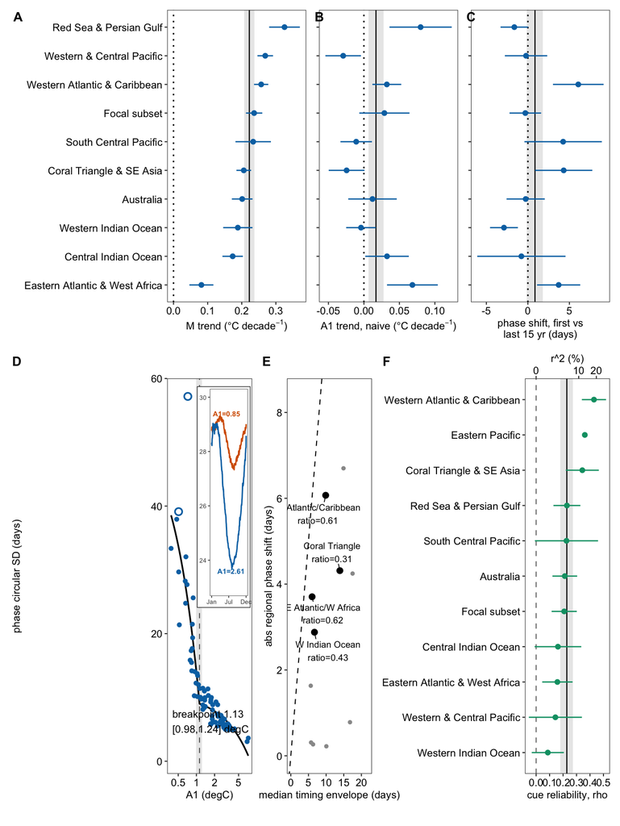

```r
top_row <- panel_A + panel_B + panel_C + plot_layout(widths = c(1, 1, 1))
bottom_row <- panel_D + panel_E + panel_F + plot_layout(widths = c(1, 1, 1))
figure2 <- top_row / bottom_row + plot_layout(heights = c(0.85, 1.15))
figure2
```

```r
dir.create("figures", showWarnings = FALSE)
ggsave("figures/figure2.pdf", figure2, width = 169, height = 225, units = "mm", device = cairo_pdf)
ggsave("figures/figure2_600dpi.png", figure2, width = 169, height = 225, units = "mm", dpi = 600)
```